# ANALYZING THE EFFECT OF VIOLENT VIDEO GAME PLAY ON MATE VALUE AND OTHER MATING RELATED VARIABLES

## Univariate Tests

```r
summary.aov(MANOVA2)
```

```
##  Response MV2Average :
##                           Df Sum Sq Mean Sq F value Pr(>F)
## VorNV                      1   0.22 0.22411  0.2797 0.5972
## Age                        1   0.39 0.38501  0.4805 0.4886
## Selfscore                  1   0.10 0.10210  0.1274 0.7213
## Gender                     1   1.49 1.48706  1.8561 0.1738
## Averagefrequencyviolence   1   0.93 0.92867  1.1591 0.2823
## VorNV:Age                  1   0.00 0.00479  0.0060 0.9384
## VorNV:Selfscore            1   1.05 1.05195  1.3130 0.2525
## VorNV:Gender               1   0.31 0.31001  0.3869 0.5343
## Selfscore:Gender           1   0.01 0.01262  0.0158 0.9002
## Age:Selfscore              1   0.02 0.01518  0.0189 0.8906
## Residuals                414 331.69 0.80119
##
##  Response MV1Total :
##                           Df Sum Sq Mean Sq F value  Pr(>F)
## VorNV                      1   18.6  18.563  0.8914 0.34566
## Age                        1   17.0  16.965  0.8147 0.36727
## Selfscore                  1   89.2  89.178  4.2822 0.03913 *
## Gender                     1  110.2 110.243  5.2937 0.02190 *
## Averagefrequencyviolence   1   13.2  13.246  0.6361 0.42559
## VorNV:Age                  1    0.9   0.866  0.0416 0.83848
## VorNV:Selfscore            1    8.2   8.174  0.3925 0.53133
## VorNV:Gender               1   14.7  14.690  0.7054 0.40146
## Selfscore:Gender           1   53.0  52.984  2.5442 0.11146
## Age:Selfscore              1    8.8   8.831  0.4241 0.51527
## Residuals                414 8621.6  20.825
## ---
## Signif. codes:  0 '***' 0.001 '**' 0.01 '*' 0.05 '.' 0.1 ' ' 1
##
##  Response SGAAverage :
##                           Df Sum Sq Mean Sq F value   Pr(>F)
## VorNV                      1   0.32  0.3171  0.1328 0.715721
## Age                        1   1.93  1.9347  0.8103 0.368565
## Selfscore                  1   3.24  3.2386  1.3563 0.244844
## Gender                     1   2.17  2.1715  0.9094 0.340821
## Averagefrequencyviolence   1   7.90  7.9043  3.3103 0.069569 .
## VorNV:Age                  1   4.28  4.2779  1.7916 0.181470
## VorNV:Selfscore            1   3.41  3.4146  1.4300 0.232446
## VorNV:Gender               1   5.26  5.2580  2.2020 0.138590
```

[output cut: 54 more lines]

```
##  Response TotalLTScore :
##                           Df  Sum Sq Mean Sq F value   Pr(>F)
## VorNV                      1    4.52  4.5235  1.8256 0.177388
## Age                        1   22.64 22.6355  9.1353 0.002663 **
## Selfscore                  1    2.72  2.7234  1.0991 0.295076
## Gender                     1   14.54 14.5378  5.8672 0.015854 *
## Averagefrequencyviolence   1    0.18  0.1779  0.0718 0.788885
## VorNV:Age                  1    1.10  1.0953  0.4421 0.506503
## VorNV:Selfscore            1    0.16  0.1629  0.0657 0.797762
## VorNV:Gender               1    5.06  5.0567  2.0408 0.153886
## Selfscore:Gender           1    0.15  0.1455  0.0587 0.808666
## Age:Selfscore              1    0.01  0.0069  0.0028 0.958004
## Residuals                414 1025.81  2.4778
## ---
## Signif. codes:  0 '***' 0.001 '**' 0.01 '*' 0.05 '.' 0.1 ' ' 1
```

```r
lm1<- lm(MV1Total ~ VorNV + Age + Selfscore + Gender + Averagefrequencyviolence + VorNV*Age + VorNV*Selfscore + VorNV*Gender + Selfscore*Gender + Age*Selfscore, data=data)
summary(lm1)
```

```
##
## Call:
## lm(formula = MV1Total ~ VorNV + Age + Selfscore + Gender + Averagefrequencyviolence +
##     VorNV * Age + VorNV * Selfscore + VorNV * Gender + Selfscore *
##     Gender + Age * Selfscore, data = data)
##
## Residuals:
##      Min       1Q   Median       3Q      Max
## -15.8120  -2.4854   0.3733   3.0908  10.0985
##
## Coefficients:
##                           Estimate Std. Error t value Pr(>|t|)
## (Intercept)              17.896535   3.021384   5.923 6.64e-09 ***
## VorNVV                    1.384323   2.488004   0.556   0.5782
## Age                       0.029589   0.070678   0.419   0.6757
## Selfscore                 0.693743   0.735793   0.943   0.3463
## GenderMale               -3.407875   1.502617  -2.268   0.0238 *
## Averagefrequencyviolence -0.018049   0.025586  -0.705   0.4809
## VorNVV:Age               -0.008551   0.050534  -0.169   0.8657
## VorNVV:Selfscore         -0.293166   0.358986  -0.817   0.4146
## VorNVV:GenderMale         1.209138   0.950162   1.273   0.2039
## Selfscore:GenderMale      0.521337   0.348684   1.495   0.1356
## Age:Selfscore            -0.011762   0.018062  -0.651   0.5153
## ---
## Signif. codes:  0 '***' 0.001 '**' 0.01 '*' 0.05 '.' 0.1 ' ' 1
##
## Residual standard error: 4.563 on 414 degrees of freedom
## Multiple R-squared:  0.03727,    Adjusted R-squared:  0.01401
## F-statistic: 1.603 on 10 and 414 DF,  p-value: 0.1033
```

```r
anova(lm1)
```

```
## Analysis of Variance Table
##
## Response: MV1Total
##                           Df Sum Sq Mean Sq F value  Pr(>F)
## VorNV                      1   18.6  18.563  0.8914 0.34566
## Age                        1   17.0  16.965  0.8147 0.36727
## Selfscore                  1   89.2  89.178  4.2822 0.03913 *
## Gender                     1  110.2 110.243  5.2937 0.02190 *
## Averagefrequencyviolence   1   13.2  13.246  0.6361 0.42559
## VorNV:Age                  1    0.9   0.866  0.0416 0.83848
## VorNV:Selfscore            1    8.2   8.174  0.3925 0.53133
## VorNV:Gender               1   14.7  14.690  0.7054 0.40146
## Selfscore:Gender           1   53.0  52.984  2.5442 0.11146
## Age:Selfscore              1    8.8   8.831  0.4241 0.51527
## Residuals                414 8621.6  20.825
## ---
## Signif. codes:  0 '***' 0.001 '**' 0.01 '*' 0.05 '.' 0.1 ' ' 1
```

```r
anova(lm1, test = "Chisq")
```

```
## Analysis of Variance Table
##
## Response: MV1Total
##                           Df Sum Sq Mean Sq F value  Pr(>F)
## VorNV                      1   18.6  18.563  0.8914 0.34566
## Age                        1   17.0  16.965  0.8147 0.36727
## Selfscore                  1   89.2  89.178  4.2822 0.03913 *
## Gender                     1  110.2 110.243  5.2937 0.02190 *
## Averagefrequencyviolence   1   13.2  13.246  0.6361 0.42559
## VorNV:Age                  1    0.9   0.866  0.0416 0.83848
## VorNV:Selfscore            1    8.2   8.174  0.3925 0.53133
## VorNV:Gender               1   14.7  14.690  0.7054 0.40146
## Selfscore:Gender           1   53.0  52.984  2.5442 0.11146
## Age:Selfscore              1    8.8   8.831  0.4241 0.51527
## Residuals                414 8621.6  20.825
## ---
## Signif. codes:  0 '***' 0.001 '**' 0.01 '*' 0.05 '.' 0.1 ' ' 1
```

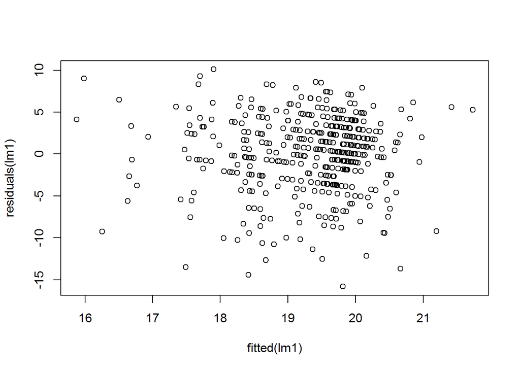

```r
plot(fitted(lm1), residuals(lm1))
```

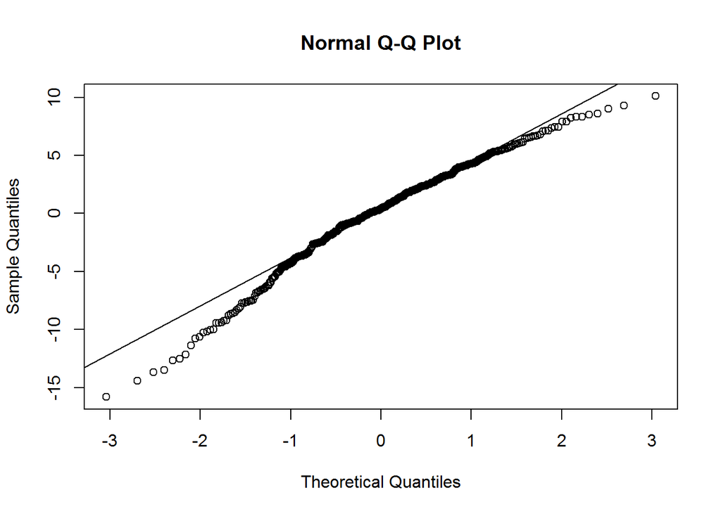

```r
qqnorm(residuals(lm1))
qqline(residuals(lm1))
```

```r
lm2<- lm(MV2Average ~ VorNV + Age + Selfscore + Gender + Averagefrequencyviolence + VorNV*Age + VorNV*Selfscore + VorNV*Gender + Selfscore*Gender + Age*Selfscore , data=data)
summary(lm2)
```

```
##
## Call:
## lm(formula = MV2Average ~ VorNV + Age + Selfscore + Gender +
##     Averagefrequencyviolence + VorNV * Age + VorNV * Selfscore +
##     VorNV * Gender + Selfscore * Gender + Age * Selfscore, data = data)
##
## Residuals:
##      Min       1Q   Median       3Q      Max
## -2.42473 -0.52583  0.09448  0.61987  2.00005
##
## Coefficients:
##                            Estimate Std. Error t value Pr(>|t|)
## (Intercept)               4.3272688  0.5926247   7.302 1.47e-12 ***
## VorNVV                    0.2671748  0.4880057   0.547    0.584
## Age                      -0.0045216  0.0138631  -0.326    0.744
## Selfscore                 0.0413861  0.1443209   0.287    0.774
## GenderMale               -0.1878517  0.2947285  -0.637    0.524
## Averagefrequencyviolence -0.0051815  0.0050186  -1.032    0.302
## VorNVV:Age               -0.0018076  0.0099119  -0.182    0.855
## VorNVV:Selfscore         -0.0842064  0.0704128  -1.196    0.232
## VorNVV:GenderMale         0.1162770  0.1863680   0.624    0.533
## Selfscore:GenderMale      0.0097528  0.0683921   0.143    0.887
## Age:Selfscore             0.0004877  0.0035427   0.138    0.891
## ---
## Signif. codes:  0 '***' 0.001 '**' 0.01 '*' 0.05 '.' 0.1 ' ' 1
##
## Residual standard error: 0.8951 on 414 degrees of freedom
## Multiple R-squared:  0.01345,    Adjusted R-squared:  -0.01038
## F-statistic: 0.5643 on 10 and 414 DF,  p-value: 0.843
```

```r
anova(lm2, test = "Chisq")
```

```
## Analysis of Variance Table
##
## Response: MV2Average
##                           Df Sum Sq Mean Sq F value Pr(>F)
## VorNV                      1   0.22 0.22411  0.2797 0.5972
## Age                        1   0.39 0.38501  0.4805 0.4886
## Selfscore                  1   0.10 0.10210  0.1274 0.7213
## Gender                     1   1.49 1.48706  1.8561 0.1738
## Averagefrequencyviolence   1   0.93 0.92867  1.1591 0.2823
## VorNV:Age                  1   0.00 0.00479  0.0060 0.9384
## VorNV:Selfscore            1   1.05 1.05195  1.3130 0.2525
## VorNV:Gender               1   0.31 0.31001  0.3869 0.5343
## Selfscore:Gender           1   0.01 0.01262  0.0158 0.9002
## Age:Selfscore              1   0.02 0.01518  0.0189 0.8906
## Residuals                414 331.69 0.80119
```

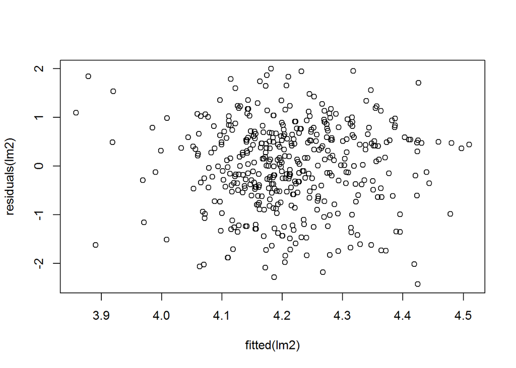

```r
plot(fitted(lm2), residuals(lm2))
```

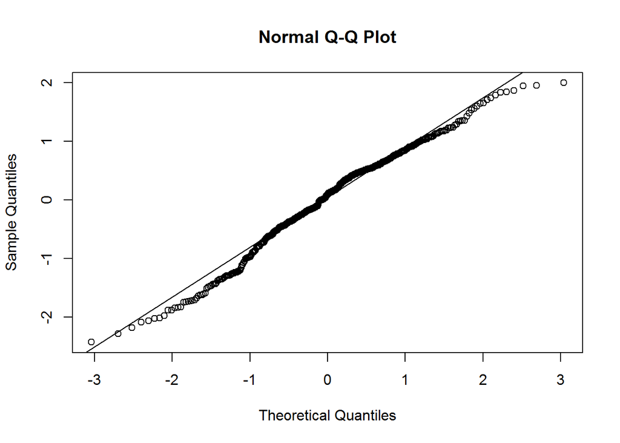

```r
qqnorm(residuals(lm2))
qqline(residuals(lm2))
```

```r
lm3<- lm(SGAAverage ~ VorNV + Age + Selfscore + Gender + Averagefrequencyviolence + VorNV*Age + VorNV*Selfscore + VorNV*Gender + Selfscore*Gender + Age*Selfscore, data=data)
summary(lm3)
```

```
##
## Call:
## lm(formula = SGAAverage ~ VorNV + Age + Selfscore + Gender +
##     Averagefrequencyviolence + VorNV * Age + VorNV * Selfscore +
##     VorNV * Gender + Selfscore * Gender + Age * Selfscore, data = data)
##
## Residuals:
##     Min      1Q  Median      3Q     Max
## -4.0663 -1.1805  0.0731  1.1855  3.7685
##
## Coefficients:
##                           Estimate Std. Error t value Pr(>|t|)
## (Intercept)               2.323584   1.023079   2.271 0.023650 *
## VorNVV                    0.448461   0.842470   0.532 0.594792
## Age                       0.019844   0.023933   0.829 0.407501
## Selfscore                 0.411297   0.249149   1.651 0.099536 .
## GenderMale                1.913346   0.508805   3.760 0.000194 ***
## Averagefrequencyviolence -0.017148   0.008664  -1.979 0.048447 *
## VorNVV:Age               -0.017276   0.017111  -1.010 0.313272
## VorNVV:Selfscore          0.152673   0.121557   1.256 0.209832
## VorNVV:GenderMale        -0.712882   0.321737  -2.216 0.027253 *
## Selfscore:GenderMale     -0.385685   0.118069  -3.267 0.001179 **
## Age:Selfscore            -0.006157   0.006116  -1.007 0.314680
## ---
## Signif. codes:  0 '***' 0.001 '**' 0.01 '*' 0.05 '.' 0.1 ' ' 1
##
## Residual standard error: 1.545 on 414 degrees of freedom
## Multiple R-squared:  0.05252,    Adjusted R-squared:  0.02964
## F-statistic: 2.295 on 10 and 414 DF,  p-value: 0.01253
```

```r
anova(lm3, test = "Chisq")
```

```
## Analysis of Variance Table
##
## Response: SGAAverage
##                           Df Sum Sq Mean Sq F value   Pr(>F)
## VorNV                      1   0.32  0.3171  0.1328 0.715721
## Age                        1   1.93  1.9347  0.8103 0.368565
## Selfscore                  1   3.24  3.2386  1.3563 0.244844
## Gender                     1   2.17  2.1715  0.9094 0.340821
## Averagefrequencyviolence   1   7.90  7.9043  3.3103 0.069569 .
## VorNV:Age                  1   4.28  4.2779  1.7916 0.181470
## VorNV:Selfscore            1   3.41  3.4146  1.4300 0.232446
## VorNV:Gender               1   5.26  5.2580  2.2020 0.138590
## Selfscore:Gender           1  23.86 23.8646  9.9944 0.001686 **
## Age:Selfscore              1   2.42  2.4198  1.0134 0.314680
## Residuals                414 988.55  2.3878
## ---
## Signif. codes:  0 '***' 0.001 '**' 0.01 '*' 0.05 '.' 0.1 ' ' 1
```

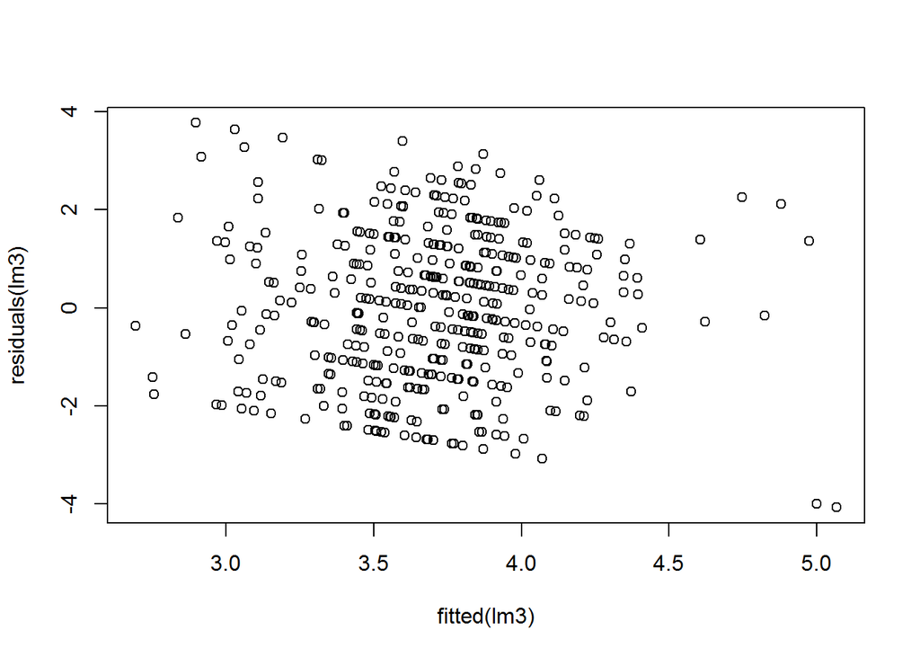

```r
plot(fitted(lm3), residuals(lm3))
```

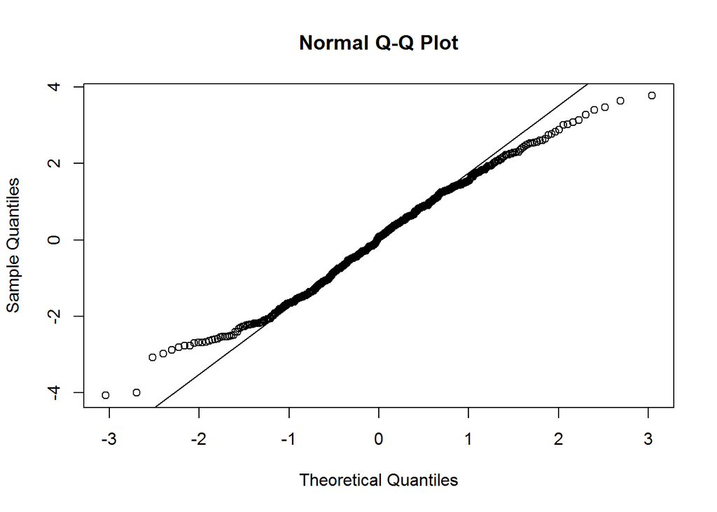

```r
qqnorm(residuals(lm3))
qqline(residuals(lm3))
```

```r
lm4<- lm(SOIRTotal ~ VorNV + Age + Selfscore + Gender + Averagefrequencyviolence + VorNV*Age + VorNV*Selfscore + VorNV*Gender + Selfscore*Gender + Age*Selfscore, data=data)
summary(lm4)
```

```
##
## Call:
## lm(formula = SOIRTotal ~ VorNV + Age + Selfscore + Gender + Averagefrequencyviolence +
##     VorNV * Age + VorNV * Selfscore + VorNV * Gender + Selfscore *
##     Gender + Age * Selfscore, data = data)
##
## Residuals:
##     Min      1Q  Median      3Q     Max
## -30.372  -9.785  -1.166   9.507  46.862
##
## Coefficients:
##                          Estimate Std. Error t value Pr(>|t|)
## (Intercept)              23.12427    9.56480   2.418  0.01605 *
## VorNVV                   -1.69960    7.87628  -0.216  0.82926
## Age                       0.08754    0.22375   0.391  0.69582
## Selfscore                 2.59876    2.32930   1.116  0.26520
## GenderMale               20.32837    4.75684   4.274 2.39e-05 ***
## Averagefrequencyviolence  0.09820    0.08100   1.212  0.22608
## VorNVV:Age                0.03032    0.15998   0.190  0.84976
## VorNVV:Selfscore          1.18558    1.13644   1.043  0.29745
## VorNVV:GenderMale        -8.35184    3.00793  -2.777  0.00574 **
## Selfscore:GenderMale     -1.81083    1.10383  -1.640  0.10166
## Age:Selfscore            -0.06501    0.05718  -1.137  0.25620
## ---
## Signif. codes:  0 '***' 0.001 '**' 0.01 '*' 0.05 '.' 0.1 ' ' 1
##
## Residual standard error: 14.45 on 414 degrees of freedom
## Multiple R-squared:  0.1446, Adjusted R-squared:  0.1239
## F-statistic: 6.996 on 10 and 414 DF,  p-value: 3.621e-10
```

```r
anova(lm4, test = "Chisq")
```

```
## Analysis of Variance Table
##
## Response: SOIRTotal
##                           Df Sum Sq Mean Sq F value    Pr(>F)
## VorNV                      1     83    82.6  0.3958   0.52960
## Age                        1   1074  1074.3  5.1476   0.02379 *
## Selfscore                  1    220   220.0  1.0540   0.30519
## Gender                     1  10657 10656.7 51.0613 4.067e-12 ***
## Averagefrequencyviolence   1    320   320.1  1.5339   0.21624
## VorNV:Age                  1     15    14.7  0.0706   0.79053
## VorNV:Selfscore            1    148   148.1  0.7095   0.40011
## VorNV:Gender               1   1343  1342.9  6.4345   0.01156 *
## Selfscore:Gender           1    472   471.8  2.2607   0.13345
## Age:Selfscore              1    270   269.8  1.2927   0.25620
## Residuals                414  86403   208.7
## ---
## Signif. codes:  0 '***' 0.001 '**' 0.01 '*' 0.05 '.' 0.1 ' ' 1
```

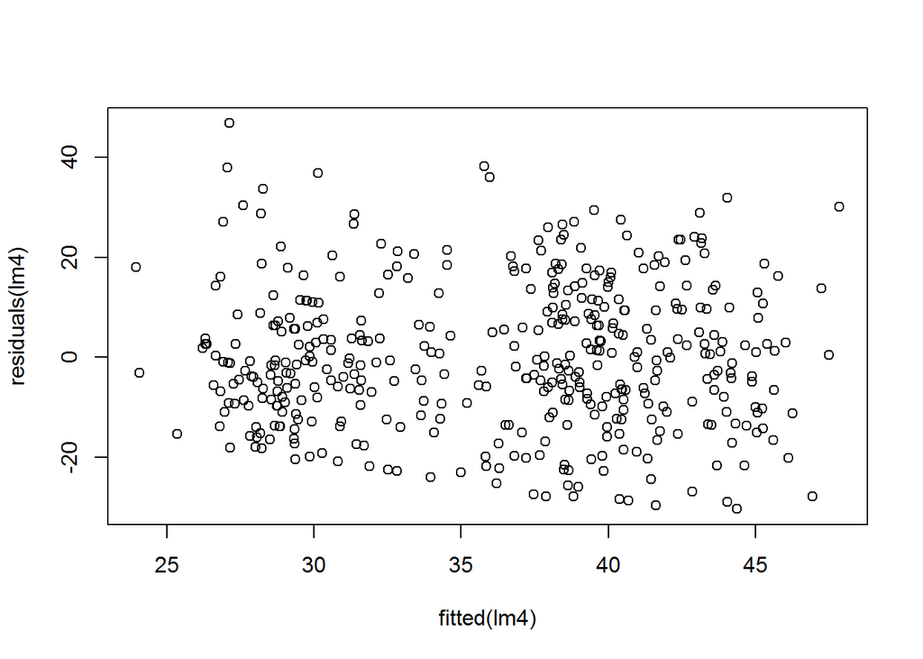

```r
plot(fitted(lm4), residuals(lm4))
```

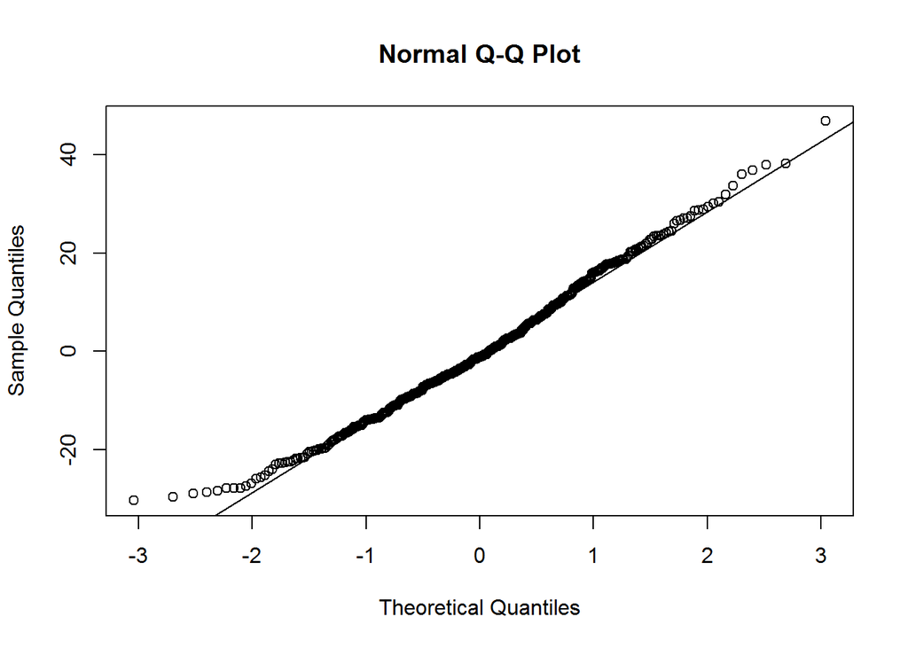

```r
qqnorm(residuals(lm4))
qqline(residuals(lm4))
```

```r
lm5<- lm(MMTotal ~ VorNV + Age + Selfscore + Gender + Averagefrequencyviolence + VorNV*Age + VorNV*Selfscore + VorNV*Gender + Selfscore*Gender + Age*Selfscore, data=data)
summary(lm5)
```

```
##
## Call:
## lm(formula = MMTotal ~ VorNV + Age + Selfscore + Gender + Averagefrequencyviolence +
##     VorNV * Age + VorNV * Selfscore + VorNV * Gender + Selfscore *
##     Gender + Age * Selfscore, data = data)
##
## Residuals:
##    Min     1Q Median     3Q    Max
## -9.060 -4.632 -1.596  3.640 19.082
##
## Coefficients:
##                            Estimate Std. Error t value Pr(>|t|)
## (Intercept)              11.2988663  3.8463066   2.938  0.00349 **
## VorNVV                    0.9556308  3.1672986   0.302  0.76302
## Age                      -0.0789124  0.0899754  -0.877  0.38097
## Selfscore                 0.4592158  0.9366849   0.490  0.62421
## GenderMale               -0.8373276  1.9128734  -0.438  0.66181
## Averagefrequencyviolence  0.0646782  0.0325722   1.986  0.04773 *
## VorNVV:Age               -0.0094431  0.0643311  -0.147  0.88337
## VorNVV:Selfscore         -0.0708294  0.4569995  -0.155  0.87691
## VorNVV:GenderMale        -0.8469159  1.2095823  -0.700  0.48421
## Selfscore:GenderMale     -0.4250457  0.4438847  -0.958  0.33884
## Age:Selfscore            -0.0006032  0.0229933  -0.026  0.97908
## ---
## Signif. codes:  0 '***' 0.001 '**' 0.01 '*' 0.05 '.' 0.1 ' ' 1
##
## Residual standard error: 5.809 on 414 degrees of freedom
## Multiple R-squared:  0.07274,    Adjusted R-squared:  0.05034
## F-statistic: 3.248 on 10 and 414 DF,  p-value: 0.0004729
```

```r
anova(lm5, test="Chisq")
```

```
## Analysis of Variance Table
##
## Response: MMTotal
##                           Df  Sum Sq Mean Sq F value    Pr(>F)
## VorNV                      1     9.2    9.17  0.2717  0.602470
## Age                        1   290.3  290.26  8.6004  0.003548 **
## Selfscore                  1     1.9    1.86  0.0552  0.814446
## Gender                     1   617.1  617.14 18.2861 2.362e-05 ***
## Averagefrequencyviolence   1   137.0  137.00  4.0592  0.044577 *
## VorNV:Age                  1     0.5    0.53  0.0157  0.900222
## VorNV:Selfscore            1     1.6    1.65  0.0489  0.825161
## VorNV:Gender               1     7.2    7.19  0.2130  0.644643
## Selfscore:Gender           1    31.3   31.27  0.9264  0.336351
## Age:Selfscore              1     0.0    0.02  0.0007  0.979084
## Residuals                414 13972.2   33.75
## ---
## Signif. codes:  0 '***' 0.001 '**' 0.01 '*' 0.05 '.' 0.1 ' ' 1
```

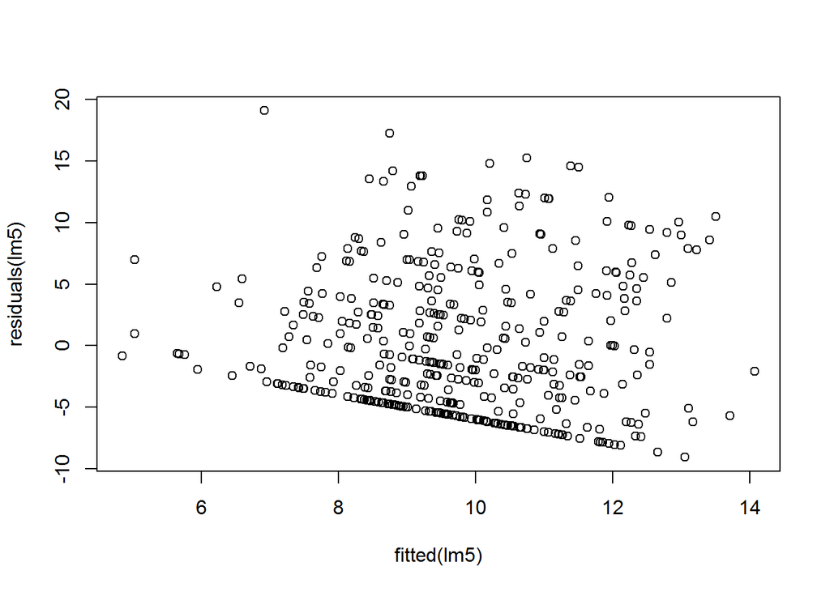

```r
plot(fitted(lm5), residuals(lm5))
```

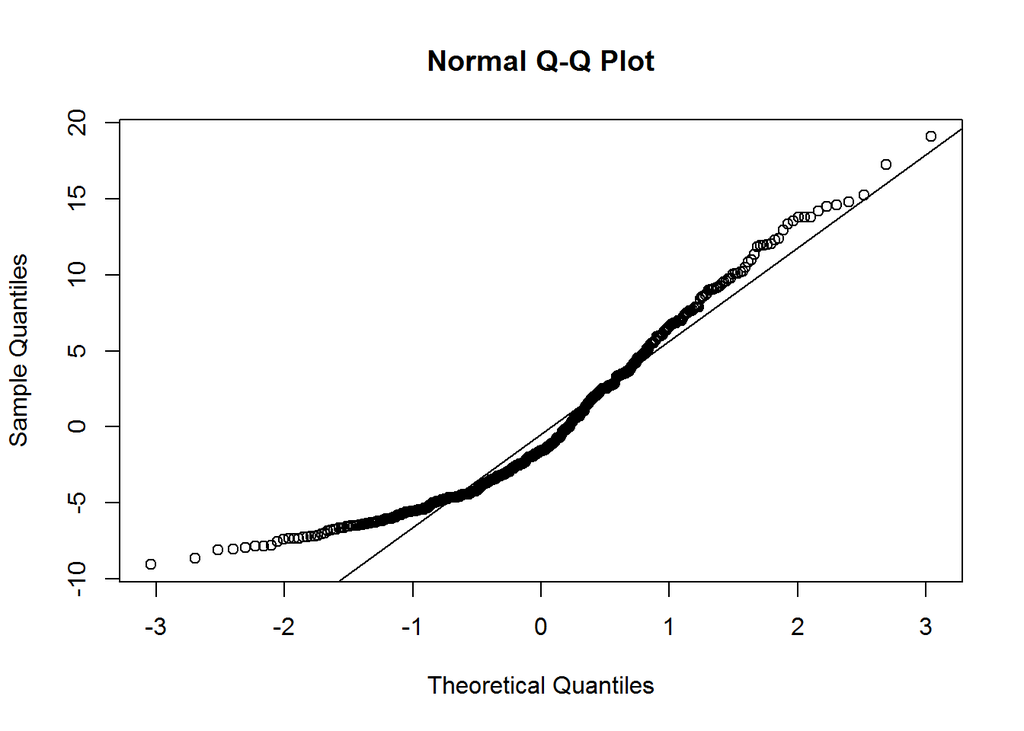

```r
qqnorm(residuals(lm5))
qqline(residuals(lm5))
```

Sex Goal Activation (SGA)

SGA and Selfscore by Gender plot

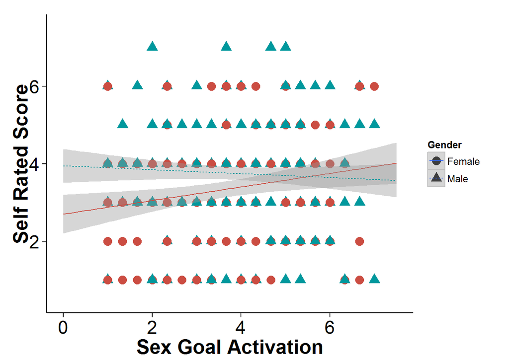

```r
plotsgaage <- ggplot(data, aes(x = SGAAverage, y = Selfscore, color = Gender, shape = Gender, linetype = Gender)) +
  geom_point(size = 4) +
  ylim(0.5,7.5) +
  scale_colour_hue(l=50, guide = FALSE) +
  scale_x_continuous(limits=c(0,7.5)) +
  theme_bw() + geom_smooth(method=lm,  fullrange=T) +
  xlab("Sex Goal Activation") +
  ylab("Self Rated Score") +
  theme(legend.position="right") +
  theme(axis.line = element_line(colour = "black"),
        axis.text=element_text(size=18),
        axis.title=element_text(size=20,face="bold"),
        axis.title.y=element_text(vjust=0.25),
        axis.title.x=element_text(vjust=0.25),
        panel.grid.major = element_blank(),
        panel.grid.minor = element_blank(),
        panel.border = element_blank(),
        panel.background = element_blank())
plotsgaage
```

Short term faces:

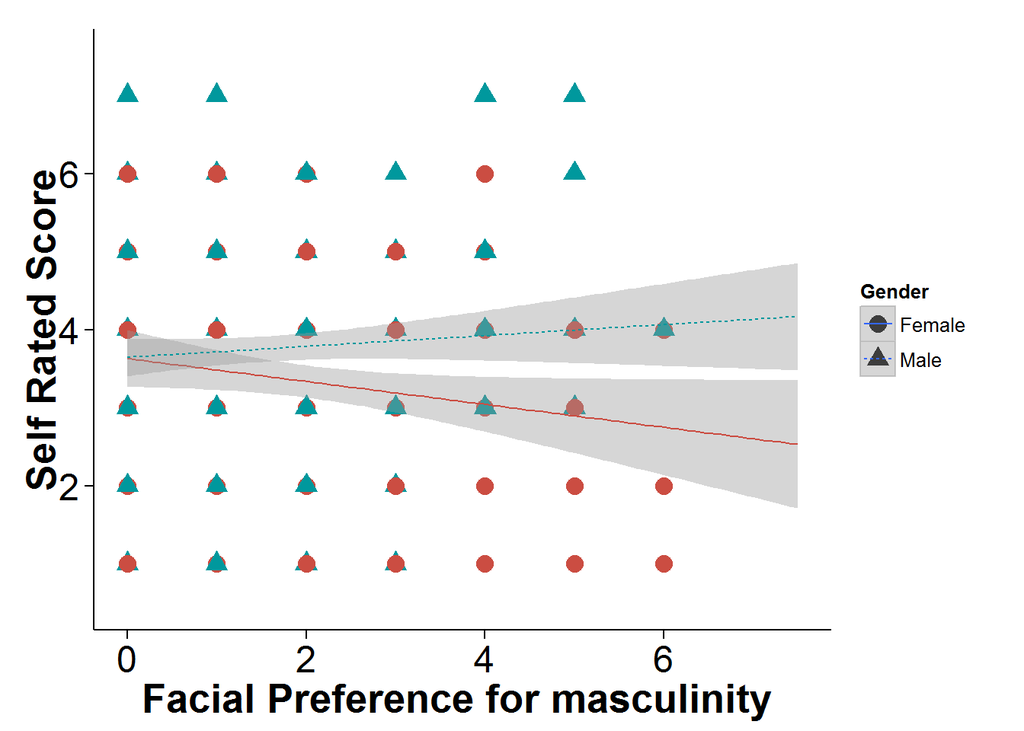

```r
plotstscore <- ggplot(data, aes(x = TotalSTScore, y = Selfscore, color = Gender, shape = Gender, linetype = Gender)) +
  geom_point(size = 4) +
  ylim(0.5,7.5) +
  scale_colour_hue(l=50, guide = FALSE) +
  scale_x_continuous(limits=c(0,7.5)) +
  theme_bw() + geom_smooth(method=lm,  fullrange=T) +
  xlab("Facial Preference for masculinity ") +
  ylab("Self Rated Score") +
  theme(legend.position="right") +
  theme(axis.line = element_line(colour = "black"),
        axis.text=element_text(size=18),
        axis.title=element_text(size=20,face="bold"),
        axis.title.y=element_text(vjust=0.25),
        axis.title.x=element_text(vjust=0.25),
        panel.grid.major = element_blank(),
        panel.grid.minor = element_blank(),
        panel.border = element_blank(),
        panel.background = element_blank())
plotstscore
```

LT Faces and age

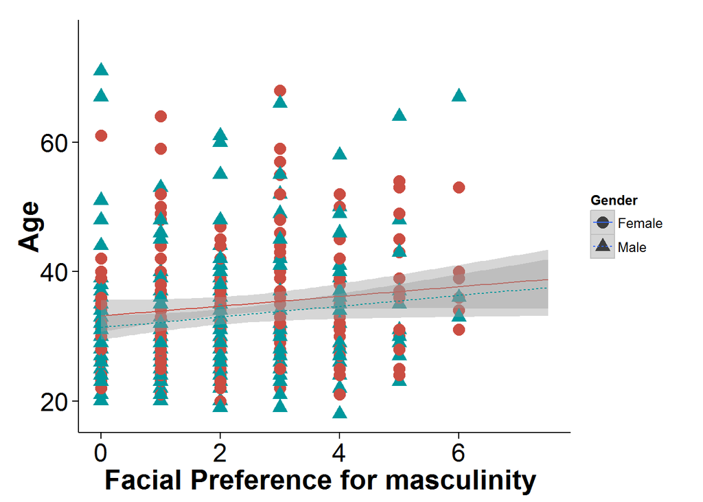

```r
plotltscore <- ggplot(data, aes(x = TotalLTScore, y = Age, color = Gender, shape = Gender, linetype = Gender)) +
  geom_point(size = 4) +
  ylim(18,76) +
  scale_colour_hue(l=50, guide = FALSE) +
  scale_x_continuous(limits=c(0,7.5)) +
  theme_bw() + geom_smooth(method=lm,  fullrange=T) +
  xlab("Facial Preference for masculinity ") +
  ylab("Age") +
  theme(legend.position="right") +
  theme(axis.line = element_line(colour = "black"),
        axis.text=element_text(size=18),
        axis.title=element_text(size=20,face="bold"),
        axis.title.y=element_text(vjust=0.25),
        axis.title.x=element_text(vjust=0.25),
        panel.grid.major = element_blank(),
        panel.grid.minor = element_blank(),
        panel.border = element_blank(),
        panel.background = element_blank())
plotltscore
```

SOIR (Revised Sociosexual Orientation Inventory)

SOIR + Averagefrequencyviolence+Gender Regression

```r
fitSOI <- lm(SOIRTotal ~ Averagefrequencyviolence + Age+ Gender, data=data)
summary(fitSOI)
```

```
##
## Call:
## lm(formula = SOIRTotal ~ Averagefrequencyviolence + Age + Gender,
##     data = data)
##
## Residuals:
##     Min      1Q  Median      3Q     Max
## -31.022 -10.246  -1.111   9.021  44.972
##
## Coefficients:
##                          Estimate Std. Error t value Pr(>|t|)
## (Intercept)              32.09620    3.23874   9.910  < 2e-16 ***
## Averagefrequencyviolence  0.09961    0.08106   1.229    0.220
## Age                      -0.09393    0.07656  -1.227    0.221
## GenderMale                9.82769    1.47828   6.648 9.23e-11 ***
## ---
## Signif. codes:  0 '***' 0.001 '**' 0.01 '*' 0.05 '.' 0.1 ' ' 1
##
## Residual standard error: 14.53 on 421 degrees of freedom
## Multiple R-squared:  0.1205, Adjusted R-squared:  0.1142
## F-statistic: 19.22 on 3 and 421 DF,  p-value: 1.065e-11
```

SOIR Age and Gender Plot

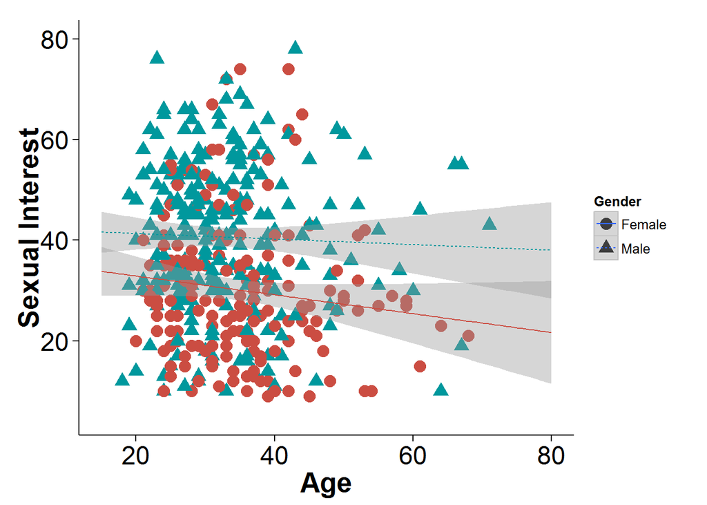

```r
plotSOI1 <- ggplot(data, aes(x = Age, y = SOIRTotal, color = Gender, shape = Gender, linetype = Gender)) +
  geom_point(size=4) +
  ylim(5,80) +
  scale_colour_hue(l=50, guide = FALSE) +
  scale_x_continuous(limits=c(15,80)) +
  theme_bw() + geom_smooth(method=lm,  fullrange=T) +
  xlab("Age") +
  ylab("Sexual Interest") +
  theme(legend.position="right") +
  theme(axis.line = element_line(colour = "black"),
        axis.text=element_text(size=18),
        axis.title=element_text(size=20,face="bold"),
        axis.title.y=element_text(vjust=0.25),
        axis.title.x=element_text(vjust=0.25),
        panel.grid.major = element_blank(),
        panel.grid.minor = element_blank(),
        panel.border = element_blank(),
        panel.background = element_blank())
plotSOI1
```

SOIR V or NV gender

```r
#plotSOI2 <- ggplot(data, aes(x = VorNV, y = SOIRTotal, color = Gender, shape = Gender, linetype = Gender)) +
#  geom_point(size=4) +
#  ylim(5,80) +
#  scale_colour_hue(l=50, guide = FALSE) +
#  scale_x_continuous(limits=c(15,80)) +
#  theme_bw() + geom_smooth(method=lm,  fullrange=T) +
#  xlab("Treatment") +
#  ylab("Sexual Interest") +
#  theme(legend.position="right") +
#  theme(axis.line = element_line(colour = "black"),
#        axis.text=element_text(size=18),
#        axis.title=element_text(size=20,face="bold"),
#        axis.title.y=element_text(vjust=0.25),
#        axis.title.x=element_text(vjust=0.25),
#        panel.grid.major = element_blank(),
#        panel.grid.minor = element_blank(),
#        panel.border = element_blank(),
#        panel.background = element_blank())
#plotSOI2
```

Mate Value Test 1 (4-Item Mate Value Scale, Edlund and Sagarin 2014)

MV1 + gender + selfscore ANOVA*

```r
MV1selfscore <- lm(MV1Total ~  Gender+ Selfscore + Selfscore*Gender, data = data)
anova(MV1selfscore, test="Chisq")
```

```
## Analysis of Variance Table
##
## Response: MV1Total
##                   Df Sum Sq Mean Sq F value  Pr(>F)
## Gender             1   69.7  69.706  3.3576 0.06760 .
## Selfscore          1  102.6 102.555  4.9399 0.02677 *
## Gender:Selfscore   1   42.9  42.874  2.0652 0.15144
## Residuals        421 8740.2  20.761
## ---
## Signif. codes:  0 '***' 0.001 '**' 0.01 '*' 0.05 '.' 0.1 ' ' 1
```

MV1 x selfscore x gender plot

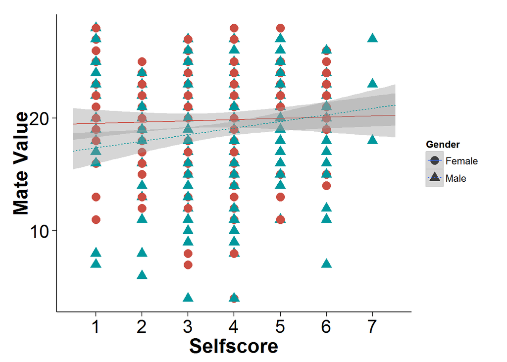

```r
plotMv1selfs <-ggplot(data, aes(x = Selfscore, y = MV1Total, color = Gender, shape = Gender, linetype = Gender)) +
  geom_point(size = 4) +
  scale_colour_hue(l=50, guide = FALSE) +
  scale_x_continuous(limits=c(0.5,7.5), breaks=c(1:7)) +
  theme_bw() + geom_smooth(method=lm,  fullrange=T) +
  xlab("Selfscore") +
  ylab("Mate Value") +
  theme(axis.line = element_line(colour = "black"),
        axis.text=element_text(size=18),
        axis.title=element_text(size=20,face="bold"),
        axis.title.y=element_text(vjust=0.25),
        axis.title.x=element_text(vjust=0.25),
        panel.grid.major = element_blank(),
        panel.grid.minor = element_blank(),
        panel.border = element_blank(),
        panel.background = element_blank())
plotMv1selfs
```

Mating motivation:

Matingmotivation + gender + selfscore + Violence exposure ANOVA

```r
MMANOVAVVG <- lm(MMTotal ~  Gender + Age + Gender*Averagefrequencyviolence + Averagefrequencyviolence + Selfscore + Selfscore*Gender, data = data)
anova(MMANOVAVVG, test="Chisq")
```

```
## Analysis of Variance Table
##
## Response: MMTotal
##                                  Df  Sum Sq Mean Sq F value    Pr(>F)
## Gender                            1   508.1  508.06 15.5826 9.265e-05 ***
## Age                               1   378.9  378.93 11.6221 0.0007150 ***
## Averagefrequencyviolence          1   143.3  143.27  4.3942 0.0366629 *
## Selfscore                         1    23.7   23.73  0.7277 0.3941149
## Gender:Averagefrequencyviolence   1   379.2  379.21 11.6308 0.0007118 ***
## Gender:Selfscore                  1     6.6    6.58  0.2017 0.6536002
## Residuals                       418 13628.5   32.60
## ---
## Signif. codes:  0 '***' 0.001 '**' 0.01 '*' 0.05 '.' 0.1 ' ' 1
```

Plot Matingmoviation and Violence Exposure

[figure not shown]

```r
plotmmavefv<- ggplot(data, aes(x = Averagefrequencyviolence, y = MMTotal, color = Gender, shape = Gender, linetype = Gender)) +
  geom_point(size=4) +
  ylim(4,30) +
  scale_colour_hue(l=50, guide = FALSE) +
  scale_x_continuous(limits=c(0,50)) +
  theme_bw() + geom_smooth(method=lm,  fullrange=T) +
  xlab("Self Score") +
  ylab("Gaming Motivation") +
  theme(legend.position="right") +
  theme(axis.line = element_line(colour = "black"),
        axis.text=element_text(size=18),
        axis.title=element_text(size=20,face="bold"),
        axis.title.y=element_text(vjust=0.25),
        axis.title.x=element_text(vjust=0.25),
        panel.grid.major = element_blank(),
        panel.grid.minor = element_blank(),
        panel.border = element_blank(),
        panel.background = element_blank())
plotmmavefv
```